# Test-a-Perceptual-Phenomenon

### Analyzing the Stroop Effect

Perform the analysis in the space below. Remember to follow [the instructions](https://docs.google.com/document/d/1-OkpZLjG_kX9J6LIQ5IltsqMzVWjh36QpnP2RYpVdPU/pub?embedded=True) and review the [project rubric](https://review.udacity.com/#!/rubrics/71/view) before submitting. Once you've completed the analysis and write-up, download this file as a PDF or HTML file, upload that PDF/HTML into the workspace here (click on the orange Jupyter icon in the upper left then Upload), then use the Submit Project button at the bottom of this page. This will create a zip file containing both this .ipynb doc and the PDF/HTML doc that will be submitted for your project.

(1) What is the independent variable? What is the dependent variable?

These variables are the two main variables in an experiment :

**Independent variable:** congruent or incongruent condition.

**Dependent variable:** Time to complete test (time spent in viewing each test).

(2) What is an appropriate set of hypotheses for this task? Specify your null and alternative hypotheses, and clearly define any notation used. Justify your choices.

(3) Report some descriptive statistics regarding this dataset. Include at least one measure of central tendency and at least one measure of variability. The name of the data file is 'stroopdata.csv'.

```python
import math
import seaborn as sns
import numpy as np
import pandas as pd
from scipy.stats import t as pt
import matplotlib.pyplot as plt
%matplotlib inline
```

```python
data = pd.read_csv("stroopdata.csv")
```

1. Reporting descriptive statistics :

```python
data.describe()
```

|  | Congruent | Incongruent |
| --- | --- | --- |
| count | 24.000000 | 24.000000 |
| mean | 14.051125 | 22.015917 |
| std | 3.559358 | 4.797057 |
| min | 8.630000 | 15.687000 |
| 25% | 11.895250 | 18.716750 |
| 50% | 14.356500 | 21.017500 |
| 75% | 16.200750 | 24.051500 |
| max | 22.328000 | 35.255000 |

(4) Provide one or two visualizations that show the distribution of the sample data. Write one or two sentences noting what you observe about the plot or plots.

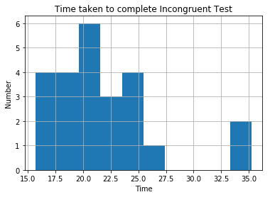

```python
# Build the visualizations here
data['Incongruent'].hist()
plt.xlabel('Time')
plt.ylabel('Number')
plt.title('Time taken to complete Incongruent Test')
```

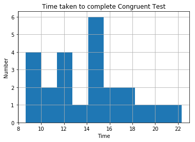

```python
data['Congruent'].hist()
plt.xlabel('Time')
plt.ylabel('Number')
plt.title('Time taken to complete Congruent Test')
```

The two histograms above shows the max number of participants in a Congruent and Incongruent tests which is 6. We can deduce from these two histograms that :

- Both the distribution are like the normal distribution with different means.

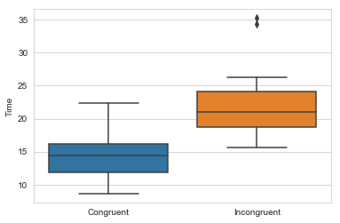

```python
sns.boxplot(data=data[['Congruent', 'Incongruent']], orient="v");
plt.ylabel("Time");
```

As seen on the histograms and on the boxplot :

- The distribution of time taken for congruent words are between 8 to 23
- The distribution of time taken for incongruent words are between ~16 to 36

(5) Now, perform the statistical test and report your results. What is your confidence level or Type I error associated with your test? What is your conclusion regarding the hypotheses you set up? Did the results match up with your expectations? **Hint:** Think about what is being measured on each individual, and what statistic best captures how an individual reacts in each environment.

**Confindence level:** 0.95

**n** = 24

```python
# Perform the statistical test here
t_critical = pt.ppf(.95, 23)
t_critical
```

```
1.7138715277470473
```

```python
diff_mean = data['Incongruent'].mean() - data['Congruent'].mean()
diff_mean
```

```
7.964791666666665
```

```python
diff_std = (data['Congruent'] - data['Incongruent']).std()
diff_std
```

```
4.864826910359056
```

**t-statistic**

```python
n = 24
t = diff_mean/(diff_std / math.sqrt(n))
t
```

```
8.020706944109955
```

As the t-statistic is higher than the t-critical value, we reject the null hypothesis.

So the time taken for congruent tasks is less than the one taken for incongruent tasks.